# Presentación

2024-07-24

## Contexto de esta presentación

Esta presentación corresponde a un proyecto de Ciencia de Datos, y forma parte del contenido requerido de la segunda tarea del Módulo 8 del Máster de Behavioral Data Analysis de la Universitat de Barcelona.

El objetivo principal del proyecto consiste en llevar a cabo una primera exploración de perfil motivacional de la población en Europa occidental; en concreto, atendemos a los principales criterios recogidos en la primera: sexo, franja de edad, nivel educativo y país.

Los objetivos específicos se recogen a continuación en su formulación como preguntas de investigación.

## Preguntas a las que este informe da respuesta

1. ¿Cómo varían las tres motivaciones contempladas (extrínseca, intrínseca y prosocial) en función del sexo de los sujetos?
2. ¿Cómo varían las tres motivaciones contempladas (extrínseca, intrínseca y prosocial) en función de la edad de los sujetos?
3. ¿Cómo varían las tres motivaciones contempladas (extrínseca, intrínseca y prosocial) en función del nivel educativo de los sujetos?
4. ¿Cómo varían las tres motivaciones contempladas (extrínseca, intrínseca y prosocial) en función del del país de los sujetos?

## 1. ¿Cómo varían las motivaciones en función del sexo?

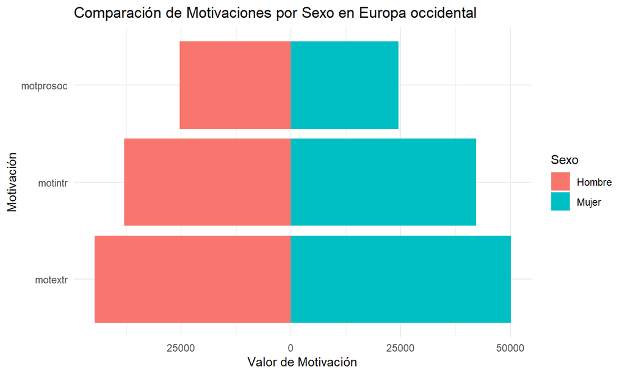

## Resultados del t-test por sexo para cada motivación

Los resultados del t-test indican que hay diferencias estadísticamente significativas entre las medias de hombres y mujeres en las tres motivaciones contempladas.

En concreto, las medias de las mujeres en motivación extrínseca (3.78) y motivación intrínseca (3.19) son más altas que las de los hombres (3.56 y 3.02), y la de los hombres lo es en motivación prosocial (2.01 frente a 1.85).

## 2. ¿Cómo varían las motivaciones en función de la edad?

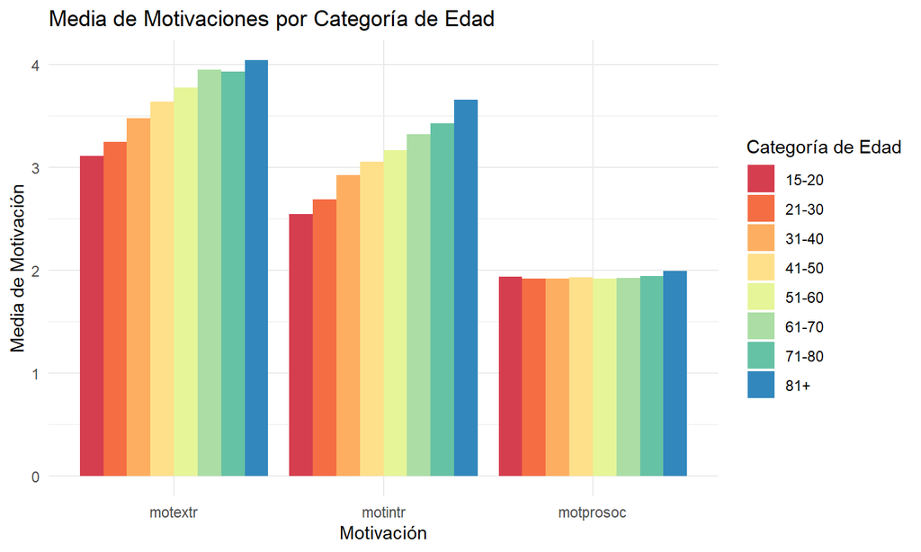

## Resultados de ANOVAs por categorías de edad para cada motivación

Los resultados de los ANOVAs indican que las diferencias entre las medias de la motivación prosocial según las categorías de edad son significativas (F(7, 25819) = 2.492, p = 0.0148).

Indican que las diferencias entre las medias de la motivación extrínseca según las categorías de edad son significativas (F(7, 25819) = 282.1, p < 0.00e+00).

Indican también que las diferencias entre las medias de la motivación intrínseca según las categorías de edad son asimismo significativas (F(7, 25819) = 366.4, p < 0.00e+00).

## 3. ¿Cómo varían las motivaciones en función del nivel educativo?

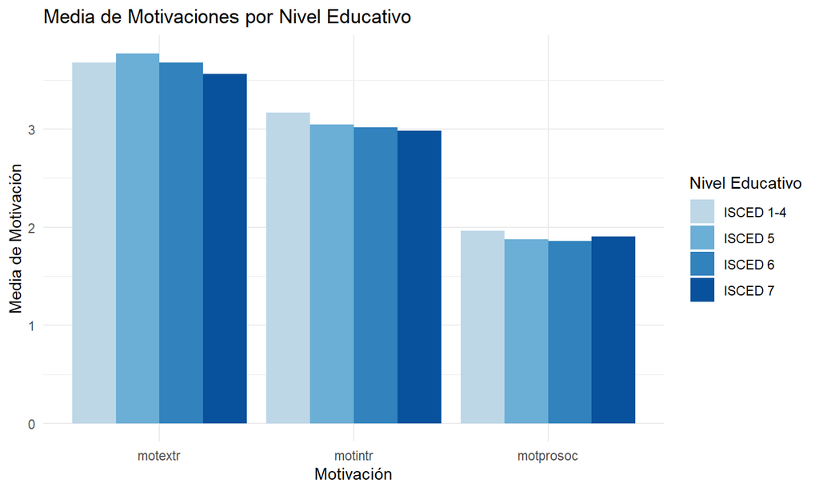

## Resultados de ANOVAs por nivel de educación para cada motivación

Los resultados de los ANOVAs indican que hay una diferencia significativa en la motivación prosocial entre los diferentes niveles educativos (F(3, 25823) = 32.08, p < 1.10e-20).

Indican que hay diferencias significativas entre los niveles educativos en motivación extrínseca (F(3, 25823) = 25.62, p < 1.53e-16) y, asimismo, que hay una diferencia significativa entre los niveles educativos en motivación intrínseca (F(3, 25823) = 59.8, p < 1.61e-38).

## 4. ¿Cómo varían las motivaciones en función del país?

Media de las motivaciones por país

| cntry | mean_Prosocial | mean_Extrínseca | mean_Intrínseca |
| --- | --- | --- | --- |
| Austria | 1.8 | 3.3 | 3.0 |
| Belgium | 1.9 | 3.4 | 2.9 |
| Denmark | 1.8 | 3.7 | 2.8 |
| Finland | 1.8 | 4.1 | 3.1 |
| France | 2.0 | 4.2 | 3.1 |
| Germany | 1.8 | 3.8 | 3.0 |
| Ireland | 1.9 | 3.7 | 3.2 |
| Italy | 2.2 | 3.1 | 3.5 |
| Netherlands | 2.0 | 3.6 | 3.0 |
| Norway | 2.1 | 3.9 | 3.2 |
| Portugal | 2.1 | 3.7 | 3.2 |
| Spain | 1.8 | 3.8 | 3.1 |
| Sweden | 2.0 | 4.0 | 3.1 |
| Switzerland | 1.8 | 3.5 | 2.7 |
| United Kingdom | 1.9 | 3.8 | 3.3 |